# Hate in Context

Week 8: Community Impacts of Hate Crime · LENS preview

Violeta Haas

Department of Political Science

School of Social Sciences and Philosophy

Trinity College Dublin

# Updates

## Organisational

### Weekly Comments

- Weekly comments due Sunday 11:59 pm (unless position-paper week)
- Keep track of used jokers (LENS: one additional joker)

### Office hours

- Slots + Zoom links are on Blackboard
- Please check the latest version (schedule was updated)
- Today: last chance to reach out for a slot if you forgot

### Week 12 topic

- How to write a research proposal
- Monday: input (structure, expectations, resources, tips)
- Wednesday: co-working session + bring questions

Causes Weeks 2–6 Demographic change  
Economic conditions  
(Social) media  
Threatening events  
Political elites

Consequences Week 8 Community impacts

Responses Weeks 9–10 Contact  
Persuasion

Guest lecture Week 11 Inclusionary policy  
Exclusionary policy

Workshop Week 12 How to write a  
research proposal

# This Week

1. Mitts (2019)
2. Branton & Kropf (2026)
3. Roman & Thompson (2024)
4. Synthesis/discussion
5. Outlook

# Mitts (2019)

[figure not shown]

Between 2011 and 2016, about 30,000 foreign fighters traveled to Syria and Iraq to join the Islamic State (Benmelech and Klor 2018). Many from Western countries.

## Overview

- **Research question:** Does local anti-Muslim hostility drive pro-ISIS radicalisation in the West?
- **Y:** online indicators of ISIS support
- **X:** local anti-Muslim hostility
- **Theory:** hostility → isolation/search for acceptance → radical messages become more attractive
- **Design/data:** geo-referenced Twitter behaviour of ISIS sympathisers in FR, UK, DE, BE

## Discussion: radicalisation

**In groups of 3–4 (≈10–15 min):**

1. How can we define radicalisation?
2. What stages of radicalisation are there?
3. Across stages, what role do social media play in recruiting and which platform types matter most where?
4. Where does Mitts’ (2019) study sit within those stages?

How can we define radicalisation?

## Q1: Definition

Among the only things radicalisation experts agree on is that radicalisation is a process (Schmid, 2013: 1), which entails the gradual adoption of extremist ideas and would end, if completed, in the practice of violent extremism or terrorism.

**Mitts’ (2019) Definition of radicalization**

Most agree that radicalization involves a change in ideology or beliefs that support indiscriminate violence against civilians for political reasons, or a group that represents this ideology and actions (Borum 2011; Sedgwick 2010; Wilner and Dubouloz 2010).

## Radicalisation as a process

- A gradual **personal and political transformation**
- A **“catalyst event”** can accelerate it ≈ Wiktorowicz’s (2005) **cognitive opening**: a shock/crisis that unsettles prior beliefs and makes new worldviews more receptive
- Catalysts can be **economic** (job loss, blocked mobility), **social** (alienation, discrimination), **political** (war, conflict), or **personal** (death of a loved one)

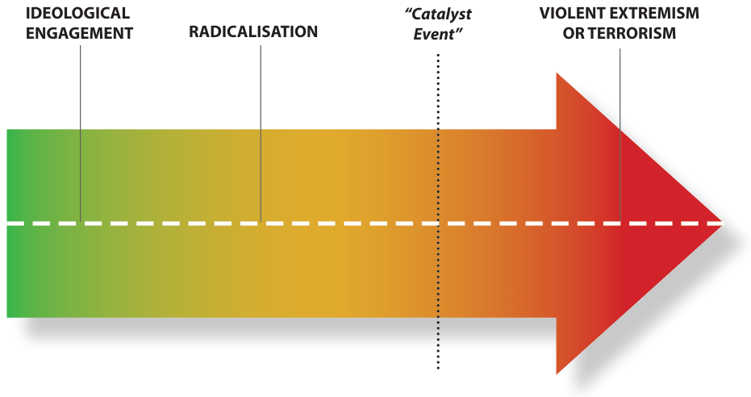

Muro (2016), Fig. 1

What stages of radicalisation are there?

## Borum: four-stage mindset

Borum (2003; 2011): how grievances and vulnerabilities turn into hatred and justification for violence (“terrorist mindset”).

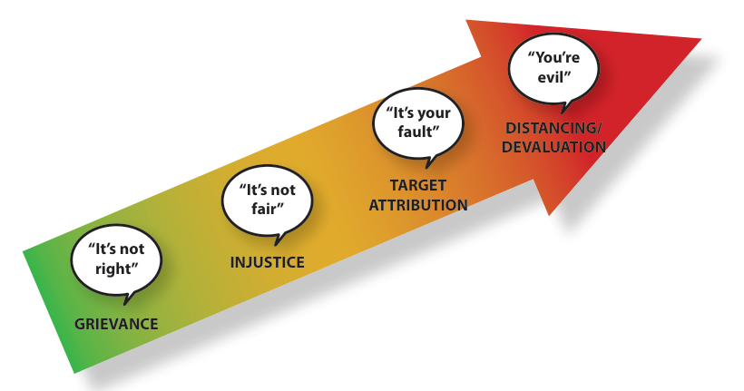

Muro (2016), Fig. 2

## Moghaddam: staircase to terrorism

Moghaddam (2005): radicalisation as a staircase, i.e., everyone starts on the ground floor, each floor is narrower (fewer people ascend) and almost none reach the top.

- **Ground:** discontent and perceived injustice/deprivation
- **1st floor:** some try to do something (seek options/solutions)
- **2nd floor:** if no solution → displace aggression onto enemy
- **3rd floor:** moral engagement with group legitimising the cause
- **4th floor:** recruitment into a terrorist organisation
- **5th floor:** trained to sidestep inhibitory mechanisms → violence/terrorist act

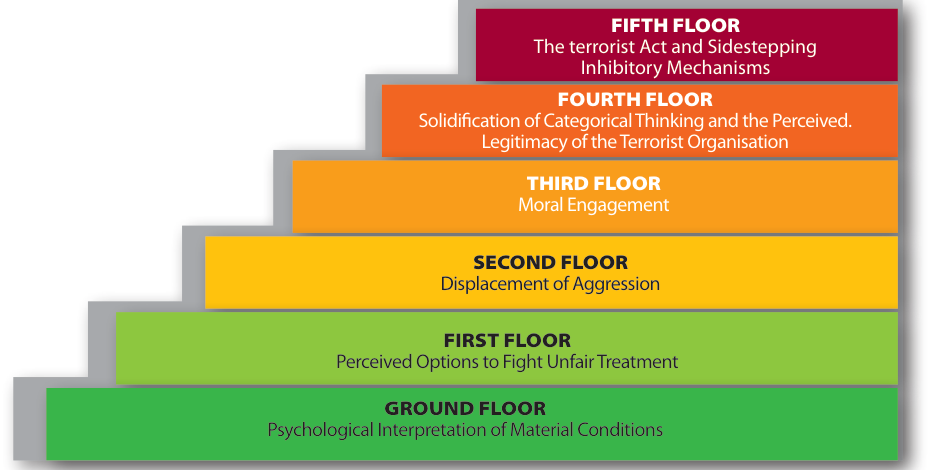

Muro (2016), Fig. 3 — built around suicide bombing; stages may not generalise everywhere

## McCauley & Moskalenko: Pyramid model

McCauley & Moskalenko (2008): Radicalisation = the gradient from a broad base of sympathisers to a tiny terrorist apex (higher on the pyramid → more commitment/fewer people).

- **Sympathisers** (base): agree with the goals terrorists claim to fight for and identify with the community they claim to represent but not violent means
- **Supporters:** justify the goals *and* the violent means
- **Activists:** do not commit the violence themselves but may provide support (recruitment, political/financial aid,…)
- **Radicals:** few active terrorists/fighters (indiscriminate violence against civilians)

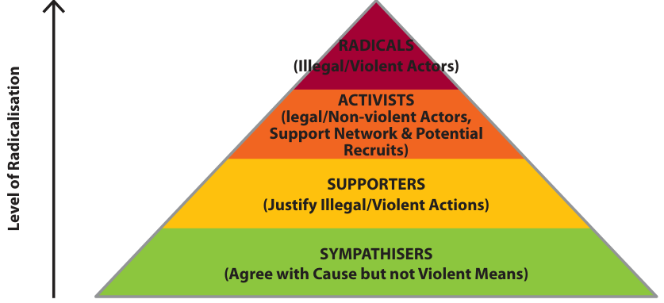

Muro (2016), Fig. 4

## Mitts’ three stages

Mitts (2019, p. 174): while models vary, **most involve three common stages**.

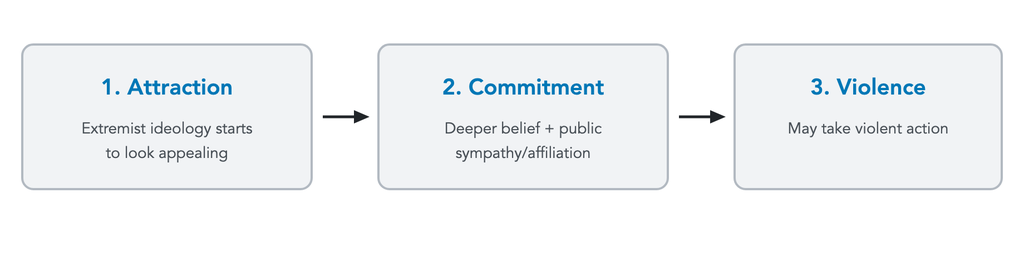

Across stages, what role do social media play in recruiting and which platform types matter most where? Draw a schematic figure.

## Q3: Role of social media

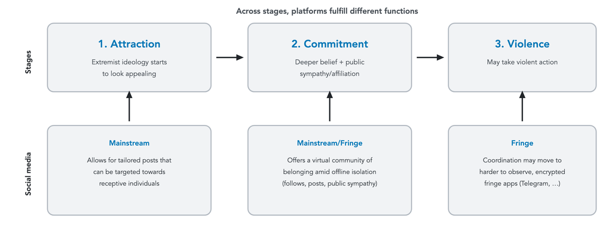

Where does Mitts’ (2019) study sit within those stages?

## Q4: Mitts concentrates on second stage

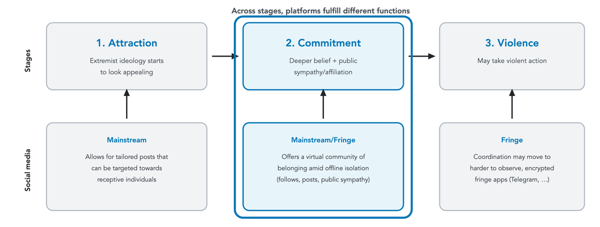

## Discussion: Mitts’ design

**Turn to a neighbor (≈4 min):**

1. How are ISIS sympathisers identified? How are they located geographically?
2. How is radicalisation (Y) measured? How is anti-Muslim hostility (X) measured?
3. Any problems you see with these measures?

How are ISIS sympathisers identified? How are they located geographically?

## Identifying and locating sympathisers

### Identified

- ISIS activists (~15,000): accounts publicly flagged by anti-ISIS hacktivist groups; scraped in real time (Dec 2015–Jan 2017) before suspension
- Followers (~1.6 million): everyone following those activist accounts

### Located

- Most users do not self-report a usable location
- Spatial label propagation (Jurgens 2013): predict a user’s offline place from the known locations of friends/followers
- Matched predicted locations to localities in FR, UK, DE, BE

How is radicalisation (Y) measured? How is anti-Muslim hostility (X) measured?

## Measuring Y and X

### Radicalisation (Y)

User-level indicators:

- Flagged as an ISIS activist
- Account suspended for ISIS links
- Number of ISIS accounts followed

Tweet content (supervised ML; human-labelled training data; EN/AR/FR/DE):

- Sympathy with ISIS
- Life in ISIS territories/travel to Syria/foreign fighters
- Anti-West rhetoric

### Anti-Muslim hostility (X)

- Main measure: local far-right/anti-Muslim party vote share (proxy for anti-Muslim animosity)
- Additional (UK): police-recorded hate crimes at force-area level — as a second X and as a moderator of the vote-share link

Any problems you see with these measures?

## Problems with these measures

- Accounts ≠ people: sockpuppets/multiple handles can inflate counts
- Location prediction is imperfect/noisy
- Far-right vote share is an imperfect proxy for hostility (also picks up elite cues). Hate-crime is a more direct measure but limited to UK.

What are the main findings?

## Findings

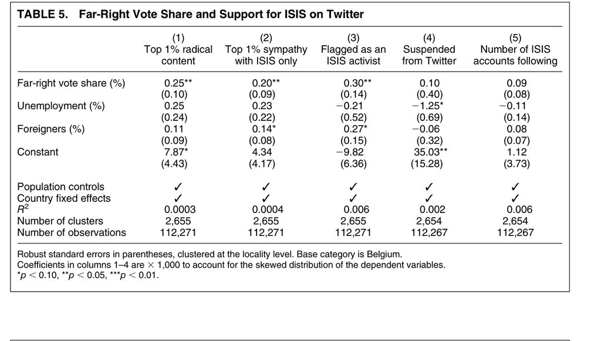

Higher local far-right vote share is associated more online radicalisation across several radicalization measures.

## Hate crimes and ISIS support (UK)

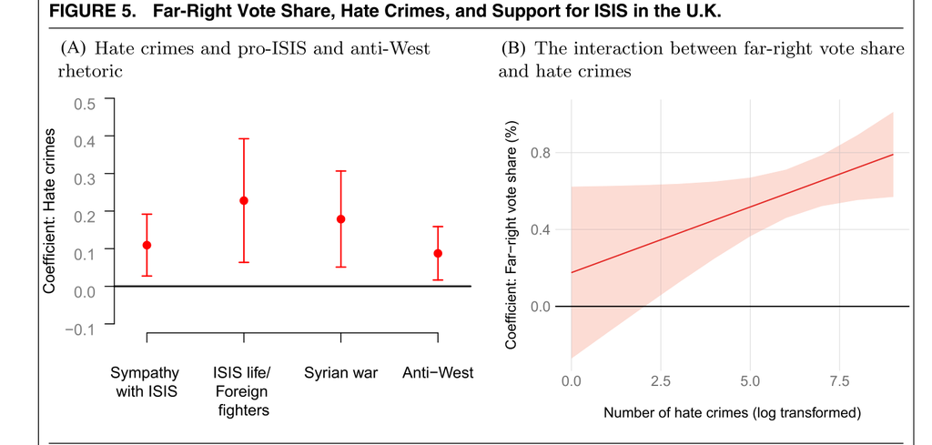

In the UK, more hate crime are associated with more pro-ISIS tweeting (A). The link between far-right vote-shares and pro-ISIS tweets is also stronger where hate crime is higher (B)

## Event responses by far-right climate

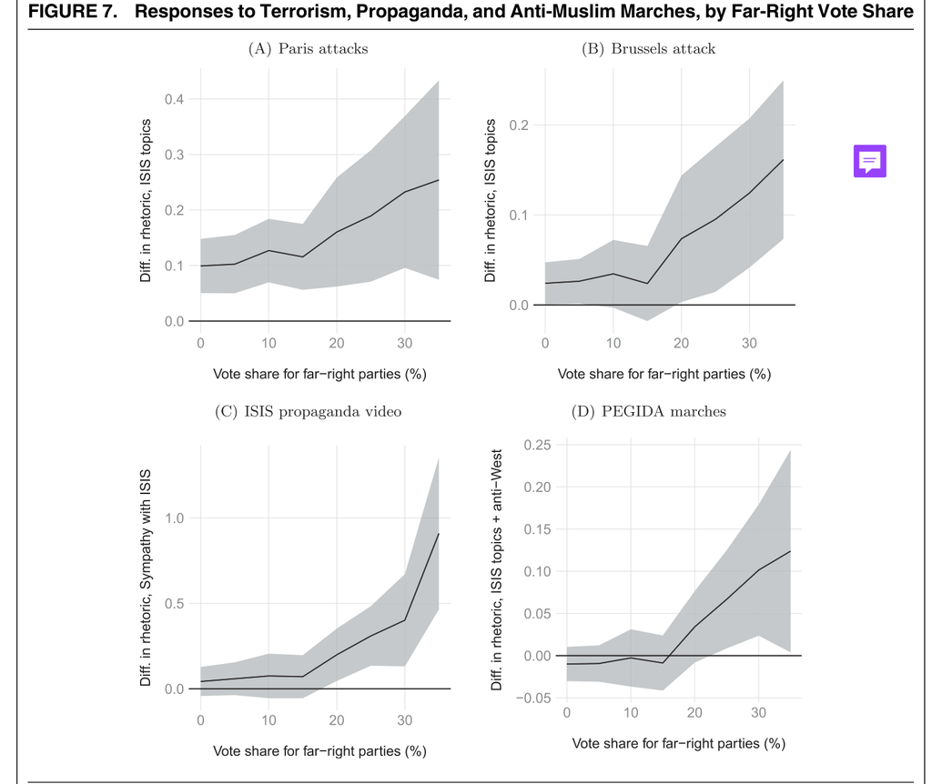

After terrorist attacks, ISIS propaganda, and PEGIDA marches, pro-ISIS rhetoric rises more where far-right vote share is higher

## A threshold for hostile climate?

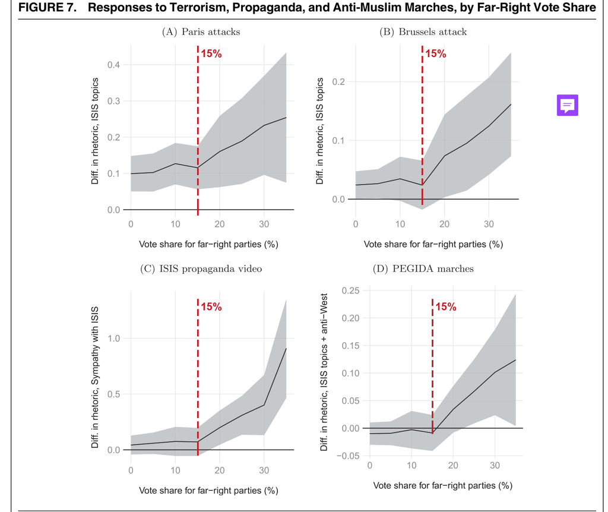

Sparse data/uncertainty in the middle of the distribution; different party systems across countries; when does far-right support become visible enough to shape norms and everyday hostility; something else?

Any surprising findings?

## A common elite/media frame

Jihadi radicalisation often framed as an “imported” problem by (far right) political elites:

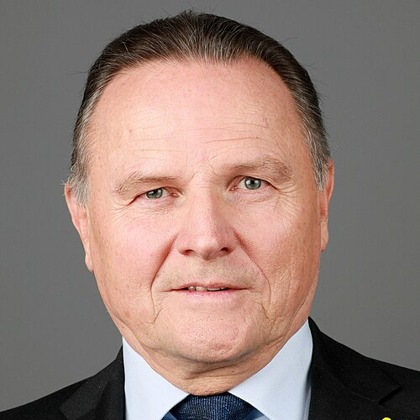

Georg Pazderski (AfD)

“Not all refugees are terrorists, but most terrorists nowadays are refugees.” (2016)

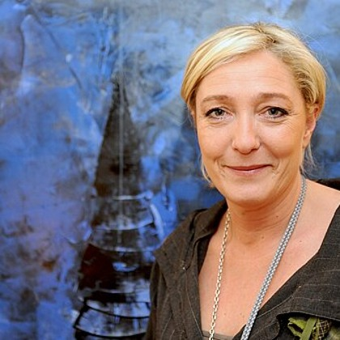

Marine Le Pen (FN)

“Multiculturalism is the soft weapon of Islamic fundamentalists…” (2017)

[figure not shown]

Charles Michel (Belgian PM)

“Almost every time, there is a link to Molenbeek.” (2015)

[figure not shown]

The Guardian (Nov 2015)

Data on Sympathizers and Activists does not support this!

## Asylum seekers (FR/DE)

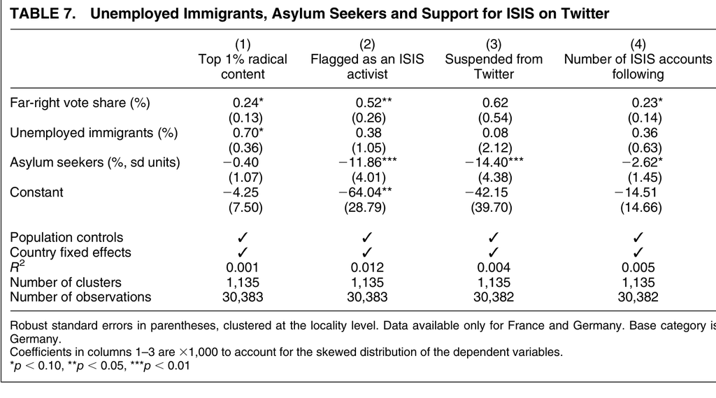

Asylum-seeker share is negatively related to pro-ISIS indicators, while far-right vote share stays positive

## Muslim share and foreigners (UK)

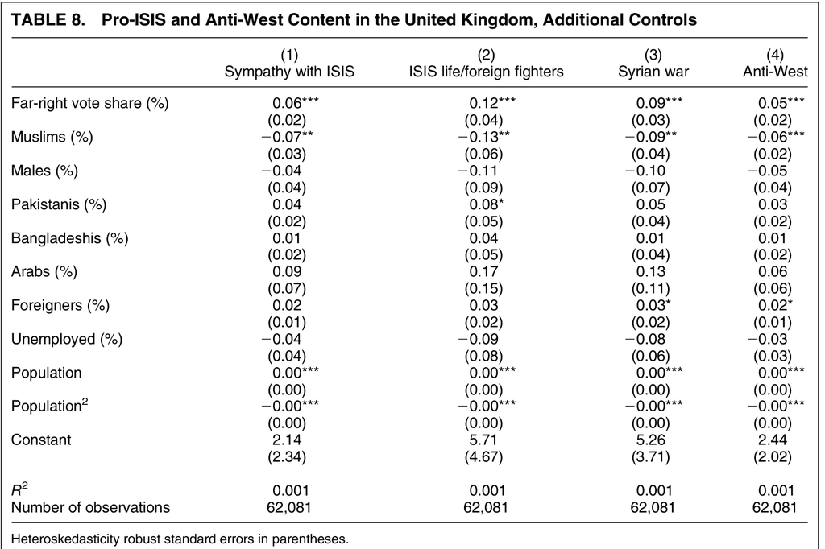

UK: % Muslim negatively correlated with pro-ISIS content; % foreigners is weak; far-right vote share remains positive and robust

## Discussion: beyond ISIS

**Turn to a neighbor (≈4 min):**

How applicable do you think these dynamics of recruitment are for other extremist groups — say, white supremacists?

Where are similarities? What might differ?

## Beyond ISIS: similarities

[discussed in class]

## Beyond ISIS: differences

[discussed in class]

Critique/Open questions?

## Open question: what about stage 1 and 3?

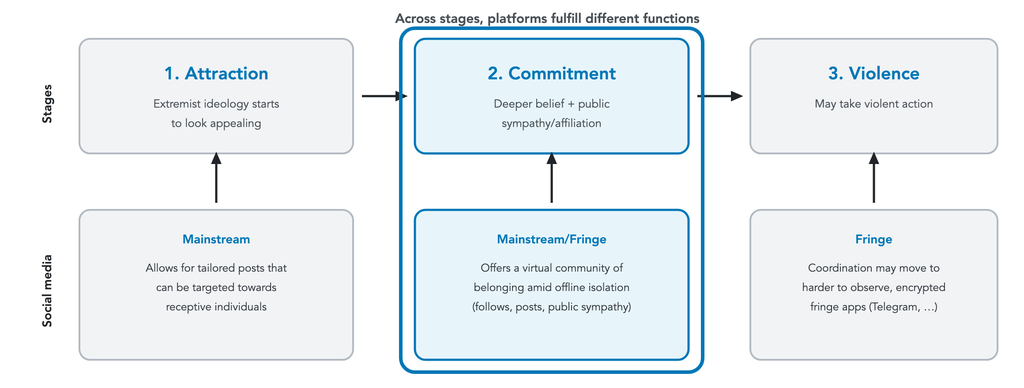

Sample concentrates on stage 2: activists + followers of ISIS accounts. We don’t know how discrimination plays out for individuals getting attracted but not yet following + some individuals might have already moved activity on to (unobserved) fringe platforms.

## Recommendations

[figure not shown]

[figure not shown]

**1. Podcast: *Transformation of European Politics***

**2. Documentary: *Radicals Rising***

[Episode 15](https://podcasts.apple.com/us/podcast/episode-15-tamar-mitts-anti-muslim-hostility-and/id1529881636?i=1000498058020) with Tamar Mitts (by [Tarik Abou-Chadi](https://www.tarikabouchadi.net/podcast.html))

[*Radicals Rising*](https://www.imdb.com/title/tt7908570/) (2016): *The Naked Truth*, S1E3 (by Mariana van Zeller)

# Branton & Kropf (2026)

Research Question: Does exposure to hate crime shape how African Americans vote?

## Theory and mechanisms

Who else is affected, and how?

[discussed in class]

Which emotions are most likely?

[discussed in class]

What behaviors do these emotions promote?

[discussed in class]

What should we expect for minority participation, given each emotion?

[discussed in class]

How to participate while avoiding risk?

[discussed in class]

Why is that still costly?

[discussed in class]

[discussed in class]

## Vote method as a function of hate crimes

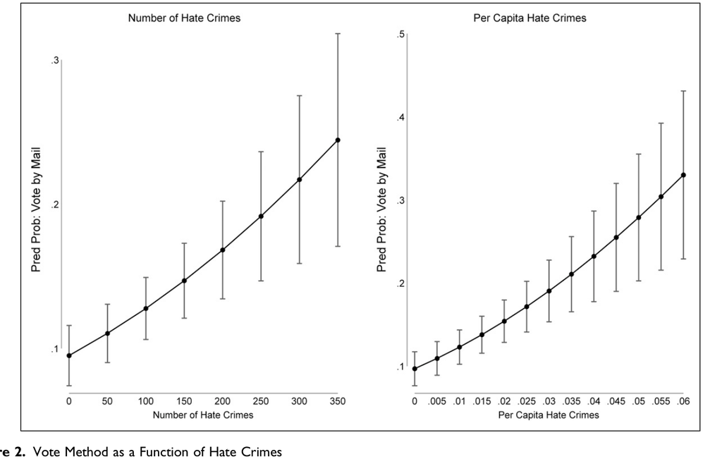

Predicted probability of VBM rises with both the number and per capita rate of local hate crimes

## Impact of hate crime on VBM

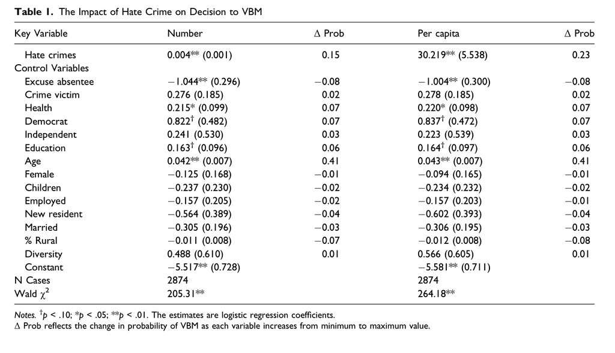

Higher county hate crime (raw count or per capita) raises the probability that African Americans vote by mail

## Critique / open questions

- **Only voters:** Y is vote *mode* among people who already voted. Demobilization into non-voting may still happen. Different sub-groups of minority groups may demobilize (not turn out at all), mobilize safely (VBM), or mobilize (turnout in person + other risk-taking actions)
- **Mechanism unobserved:** no direct measures of fear vs anger, perceived safety, or awareness of local hate crimes
- **Open question:** What would we expect in contexts where VBM is not an option?

# Roman & Thompson (2024)

Research question: Does indirect exposure to violence against LGBTQ+ people make the mass public more prosocial toward LGBTQ+ people?

## Exercise: stylized expectations

How does the public react in response to violent events against marginalized groups?

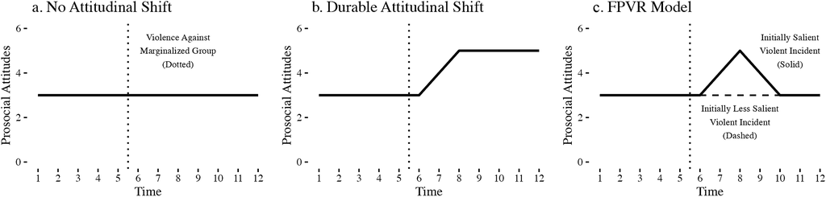

**Split into three groups (≈5 min):**

1. Each group takes **one panel** (a / b / c)
2. Formulate **2 reasons** why that expectation should materialize

## Stylized expectations

[discussed in class]

## Fickle Prosocial Violence Response model

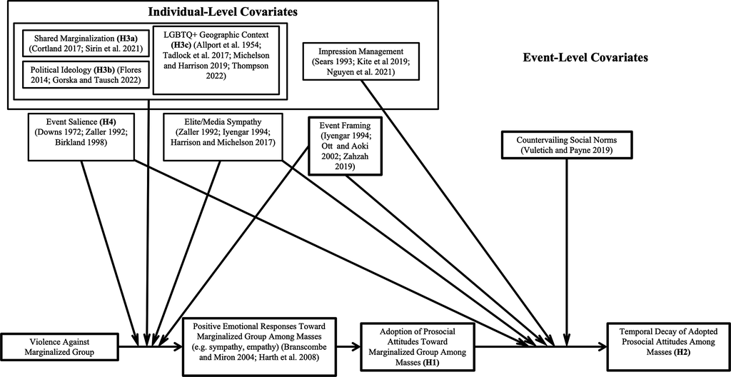

## SSM support increases post-Pulse

**Pulse:** June 2016 massacre at Pulse, an LGBTQ+ nightclub in Orlando

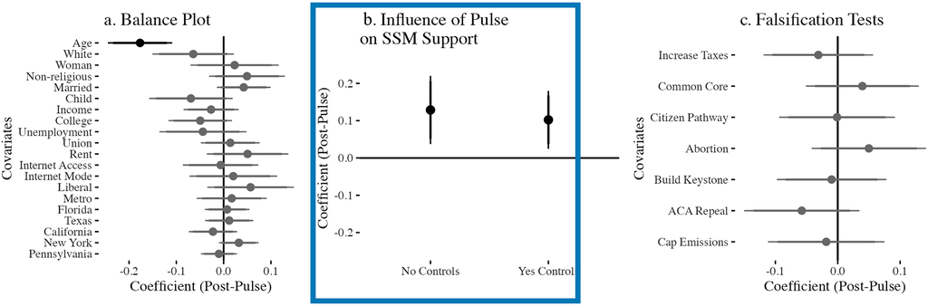

Post-Pulse respondents more supportive of same-sex marriage

## Pulse effect attenuates over time

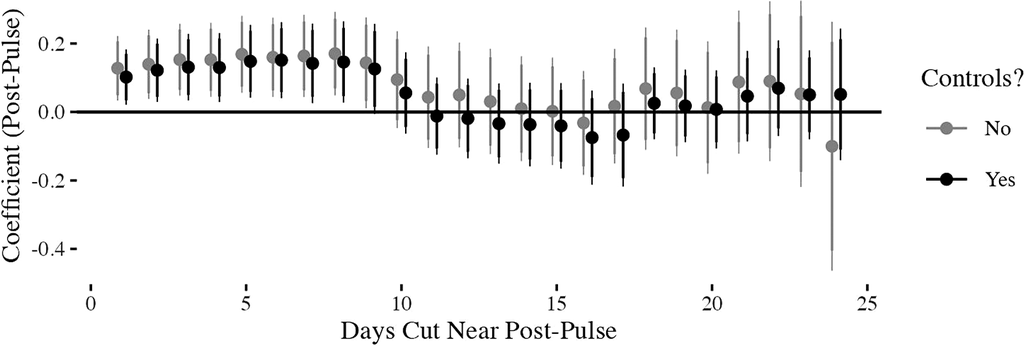

The prosocial shift is short-lived, consistent with the “fickle” FPVR prediction

## Anti-gay attitudes after Pulse

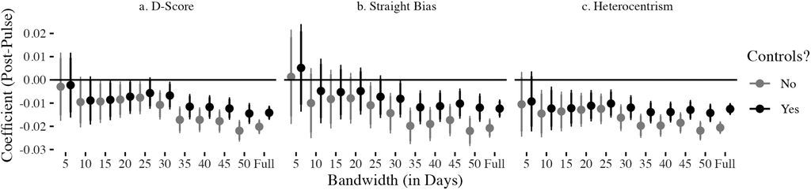

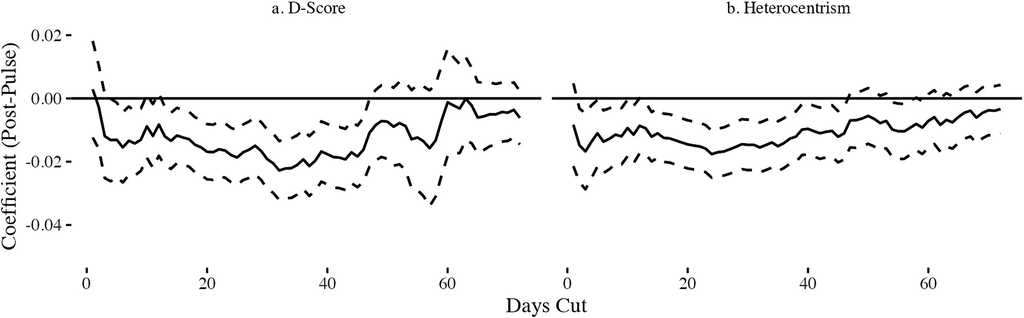

Top: post-Pulse cuts implicit and explicit anti-gay bias (D-score, straight bias, heterocentrism) across bandwidths.  
Bottom: that reduction holds for ~50 days, then fades. Same “fickle” pattern as SSM support

Critique/Open questions?

Local, low-salience crimes by out-group members can spark majority retaliation (Riaz et al. 2024), while majority prosociality toward minorities seems to need highly salient events (Roman and Thompson 2024).

# Synthesis

## Exercise: sort the readings

In pairs (≈5 min): place today’s readings. Any earlier required readings that also fit?

whose reaction is observed

Minority group

Majority group

who discriminates/enacts violence

Bottom-up  
hostility

Bottom-up discrimination → minority outcomes

Bottom-up discrimination → majority outcomes

Top-down  
hostility

Top-down discrimination → minority outcomes

Top-down discrimination → majority outcomes

## Exercise: sort the readings

[discussed in class]

# Outlook

## Next week: reducing hate crime I — contact

**Week 9** (Mon 9/Wed 11 Nov): intergroup contact as a remedy?

**Required readings**

- Mousa, S. (2020). Building social cohesion between Christians and Muslims through soccer in post-ISIS Iraq. *Science*, 369(6505), 866–870.
  - Scope Conditions. (n.d.). The promise and limits of intergroup contact, with Salma Mousa [Audio podcast episode]. *Scope Conditions Podcast*.
- Alrababa’h, A., Marble, W., Mousa, S., & Siegel, A. A. (2021). Can exposure to celebrities reduce prejudice? The effect of Mohamed Salah on Islamophobic behaviors and attitudes. *American Political Science Review*, 115(4), 1111–1128.
- Scacco, A., & Warren, S. S. (2018). Can social contact reduce prejudice and discrimination? Evidence from a field experiment in Nigeria. *American Political Science Review*, 112(3), 654–677.

Weekly comments due **Sunday 8 Nov, 11:59 pm**.